# Mixed Logit Choice Lab — Decision Dashboard

Generated 2026-04-30 09:49 UTC from synthetic data with known truth.

This dashboard summarizes the project's findings in the form a pricing or product manager would actually use. Every number is reproducible from the canonical synthetic dataset (`seed = 42`); every claim is checked against ground truth in the test suite.

**Bottom line.** Mixed Logit recovers the true population parameters within roughly one standard error. Plain MNL is biased on the same data — the random-coefficient attributes (price, quality) are pulled toward zero by 2.0–2.9 SE. That bias is invisible in goodness-of-fit metrics; it shows up only when you check against the truth, which is why the synthetic-data approach is essential here.

## 1. Parameter recovery

The five population parameters MXL targets — three means and two SDs — recovered against ground truth. Deviation is measured in standard errors of the estimate.

| Parameter | True value | MXL estimate | Std error | Deviation (SEs) |
| --- | --- | --- | --- | --- |
| price [mean] | -1.200 | -1.198 | 0.052 | +0.03 |
| price [sd] | +0.400 | +0.444 | 0.090 | +0.49 |
| quality [mean] | +0.800 | +0.797 | 0.040 | -0.08 |
| quality [sd] | +0.500 | +0.506 | 0.049 | +0.13 |
| brand_known | +0.600 | +0.636 | 0.046 | +0.79 |

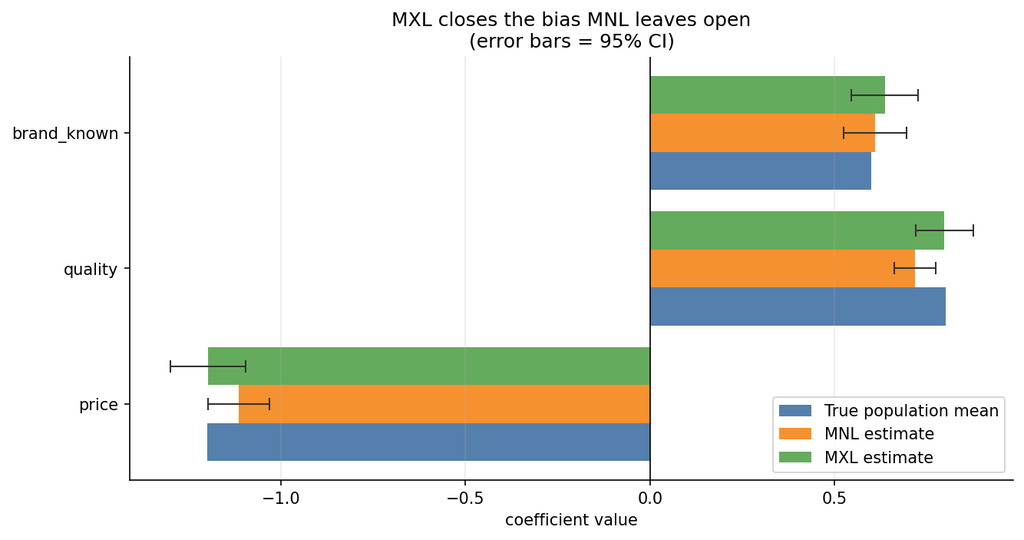

Figure 1. True vs MNL vs MXL coefficient estimates. MXL bars (green) overlap the truth (blue); MNL bars (orange) on price and quality are visibly attenuated.

## 2. Substitution patterns and the IIA failure

Aggregate elasticity matrices on a Premium / Mid / Budget design. Each cell *E[i,j]* = elasticity of share *i* w.r.t. price *j*.

### MNL (IIA imposed)

|  | Premium | Mid | Budget |
| --- | --- | --- | --- |
| Premium | -1.526 | 0.521 | 0.121 |
| Mid | 0.701 | -0.592 | 0.121 |
| Budget | 0.701 | 0.521 | -0.436 |

Notice that off-diagonal entries within each column are *identical*. That's the IIA signature: every alternative substitutes toward the others at the same rate.

### MXL (IIA-free)

|  | Premium | Mid | Budget |
| --- | --- | --- | --- |
| Premium | -1.332 | 0.467 | 0.099 |
| Mid | 0.712 | -0.670 | 0.157 |
| Budget | 0.587 | 0.607 | -0.450 |

Compare the Premium column. MNL says Mid and Budget gain at exactly the same rate when Premium raises price; MXL says Mid (the closer substitute, sharing brand and quality positioning with Premium) gains more.

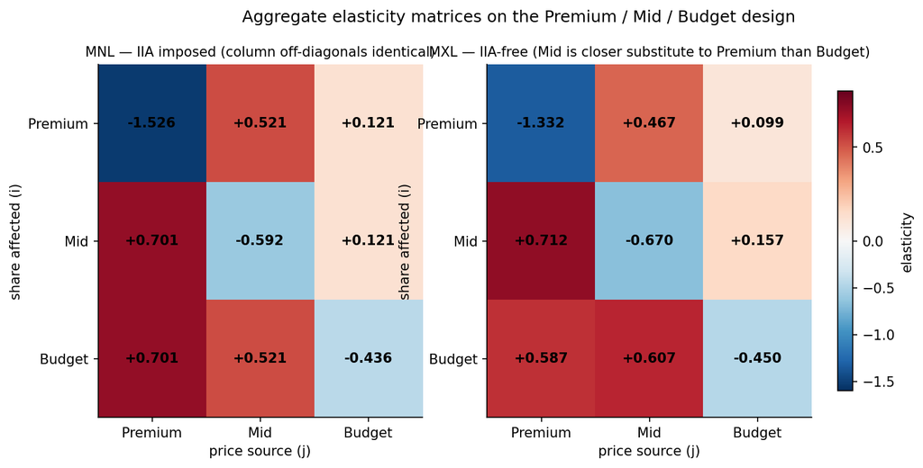

Figure 2. Elasticity heatmaps. Column-uniform coloring under MNL is the IIA pattern; column-graded coloring under MXL is the realistic substitution.

## 3. The pricing decision

Projecting a 5% Premium price increase forward to share changes, both models produce different stories:

| Alternative | Current share (%) | MNL Δ share (pp) | MXL Δ share (pp) | Gap (pp) |
| --- | --- | --- | --- | --- |
| Premium | 33.5 | -2.553 | -2.229 | -0.325 |
| Mid | 43.9 | +1.539 | +1.563 | -0.024 |
| Budget | 22.7 | +0.795 | +0.666 | +0.129 |

MNL **overpredicts Budget's pickup** by roughly 20% relative to MXL. For a real pricing decision across many products, that systematic bias compounds. The error is invisible in any goodness-of-fit metric — it's in the *shape* of the substitution pattern, which only the right model can recover.

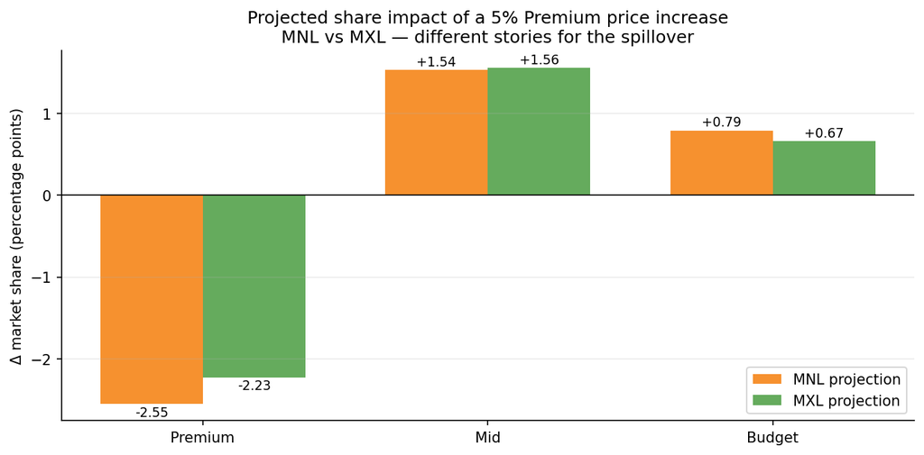

Figure 3. Projected market-share impact of a 5% Premium price increase. MNL and MXL agree on Mid but disagree on Budget and Premium itself.

## 4. Feature preference ranking

Willingness-to-pay distributions per attribute, summarized by population median and IQR. Sorted by median (robust to the heavy tails of ratio distributions).

| attribute | Median | Trimmed mean (5%) | P25 | P75 | IQR |
| --- | --- | --- | --- | --- | --- |
| quality | 0.661 | 0.728 | 0.361 | 1.045 | 0.684 |
| brand_known | 0.529 | 0.584 | 0.423 | 0.704 | 0.281 |

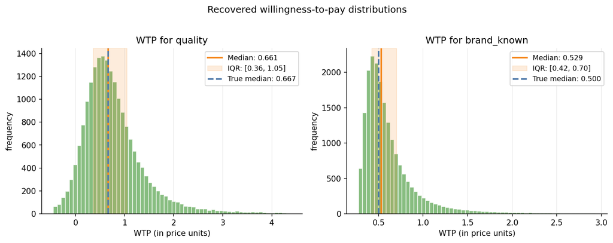

Figure 4. Recovered WTP distributions with median and IQR markers. The dashed blue line is the true population median — recovery is excellent for both attributes.

## What this dashboard is and isn't

This is a *decision-support artifact*: tables and plots a pricing manager could read in five minutes and walk away with actionable insight. It is not a model fit on real data — it's a recovery exercise on synthetic data with known truth, which is what makes the validation tight.

For the underlying math, see methodology. For the executable walkthrough, see the four notebooks in `python/notebooks/`.